# Carolina Data Challenge: NFL

Abigail Wingo and Alexander Morton

October 4, 2020

We created this analysis for the Carolina Data Challenge. We were given NFL cumulative statistics from 2000 to 2013. We worked to create a model to show which variables best predicted the point difference in any given NFL game. This information would be applied to predict the point difference for future games, given average statistics for each significant variable, in order to set a realistic line used for betting.

First, we imported all of our data as separate dataframes for each year.

```r
library(RCurl)
x <- getURL("https://raw.githubusercontent.com/Carolina-Data-Challenge/datasets/main/FootballDatasets/NFL/CumulativeStats/nfl2000stats.csv")
NFL2000 <- read.csv(text = x)

x <- getURL("https://raw.githubusercontent.com/Carolina-Data-Challenge/datasets/main/FootballDatasets/NFL/CumulativeStats/nfl2001stats.csv")
NFL2001 <- read.csv(text = x)

x <- getURL("https://raw.githubusercontent.com/Carolina-Data-Challenge/datasets/main/FootballDatasets/NFL/CumulativeStats/nfl2002stats.csv")
NFL2002 <- read.csv(text = x)

x <- getURL("https://raw.githubusercontent.com/Carolina-Data-Challenge/datasets/main/FootballDatasets/NFL/CumulativeStats/nfl2003stats.csv")
NFL2003 <- read.csv(text = x)

x <- getURL("https://raw.githubusercontent.com/Carolina-Data-Challenge/datasets/main/FootballDatasets/NFL/CumulativeStats/nfl2004stats.csv")
NFL2004 <- read.csv(text = x)

x <- getURL("https://raw.githubusercontent.com/Carolina-Data-Challenge/datasets/main/FootballDatasets/NFL/CumulativeStats/nfl2005stats.csv")
NFL2005 <- read.csv(text = x)

x <- getURL("https://raw.githubusercontent.com/Carolina-Data-Challenge/datasets/main/FootballDatasets/NFL/CumulativeStats/nfl2006stats.csv")
NFL2006 <- read.csv(text = x)

x <- getURL("https://raw.githubusercontent.com/Carolina-Data-Challenge/datasets/main/FootballDatasets/NFL/CumulativeStats/nfl2007stats.csv")
NFL2007 <- read.csv(text = x)

x <- getURL("https://raw.githubusercontent.com/Carolina-Data-Challenge/datasets/main/FootballDatasets/NFL/CumulativeStats/nfl2008stats.csv")
NFL2008 <- read.csv(text = x)

x <- getURL("https://raw.githubusercontent.com/Carolina-Data-Challenge/datasets/main/FootballDatasets/NFL/CumulativeStats/nfl2009stats.csv")
NFL2009 <- read.csv(text = x)

x <- getURL("https://raw.githubusercontent.com/Carolina-Data-Challenge/datasets/main/FootballDatasets/NFL/CumulativeStats/nfl2010stats.csv")
NFL2010 <- read.csv(text = x)

x <- getURL("https://raw.githubusercontent.com/Carolina-Data-Challenge/datasets/main/FootballDatasets/NFL/CumulativeStats/nfl2011stats.csv")
NFL2011 <- read.csv(text = x)

x <- getURL("https://raw.githubusercontent.com/Carolina-Data-Challenge/datasets/main/FootballDatasets/NFL/CumulativeStats/nfl2012stats.csv")
NFL2012 <- read.csv(text = x)

x <- getURL("https://raw.githubusercontent.com/Carolina-Data-Challenge/datasets/main/FootballDatasets/NFL/CumulativeStats/nfl2013stats.csv")
NFL2013 <- read.csv(text = x)
```

The more recent data sets had 2 extra variables, so we removed them so all the data would be consistent.

```r
NFL2009 <- NFL2009[-c(13,29)]
NFL2010 <- NFL2010[-c(13,29)]
NFL2011 <- NFL2011[-c(13,29)]
NFL2012 <- NFL2012[-c(13,29)]
NFL2013 <- NFL2013[-c(13,29)]
```

The earlier data sets variable Total Line was named differently, so we editted it for consistency.

```r
colnames(NFL2002)[33] <- "TotalLine"
colnames(NFL2003)[33] <- "TotalLine"
colnames(NFL2004)[33] <- "TotalLine"
colnames(NFL2005)[33] <- "TotalLine"
colnames(NFL2006)[33] <- "TotalLine"
colnames(NFL2007)[33] <- "TotalLine"
```

Next, we combined the 2002 to 2013 datasets, excluding the 2000 and 2001 datasets because they were missing two variables, Line and Total Line.

```r
NFL <- rbind(NFL2002, NFL2003, NFL2004, NFL2005, NFL2006, NFL2007, NFL2008, NFL2009, NFL2010, NFL2011, NFL2012, NFL2013)
NFL$PointDifference <- (NFL$ScoreOff - NFL$ScoreDef)
```

One of the metrics was taken using percentages, so we removed the “%” from the numbers so the variable would be numeric.

```r
NFL$ThirdDownPctOff = as.numeric(gsub("[\\%,]", "", NFL$ThirdDownPctOff))
NFL$ThirdDownPctDef = as.numeric(gsub("[\\%,]", "", NFL$ThirdDownPctDef))
```

Here, we added a variable of whether the team won or lost that game, using 0 as a loss and 1 as a win.

```r
NFL$W.L <- 0
for (i in 1:nrow(NFL)) {
  if (NFL$PointDifference[i] > 0) {
    NFL$W.L[i] = 1
  }
}
```

Next, we converted the time of possession to seconds in order to use it as a numeric value in the analysis.

```r
library(stringr)
NFL$SecondsOff <- (as.numeric(str_sub(NFL$TimePossOff, end=-4))*60) + (as.numeric(str_sub(NFL$TimePossOff, start=-2)))
NFL$SecondsDef <- (as.numeric(str_sub(NFL$TimePossDef, end=-4))*60) + (as.numeric(str_sub(NFL$TimePossDef, start=-2)))
```

We used this function created by Professor McLean at UNC Chapel Hill to find the most significant variables to create the best model.

```r
ShowSubsets=function(regout){
  z=summary(regout)
  q=as.data.frame(z$outmat)
  q$Rsq=round(z$rsq*100,2)
  q$adjRsq=round(z$adjr2*100,2)
  q$Cp=round(z$cp,2)
  return(q)
}
```

In order to perform a regression analysis, we had to move the PointDifference to the last column.

```r
NFL.2 <- NFL[c(1:33, 35:37, 34)]
```

Next, we removed variables that were not numeric or that were not needed for the analysis.

```r
NFL.3 <- NFL.2[-c(1:3, 13, 15, 17, 18, 28, 30,31,33,34)]
```

We removed any rows that had null values.

```r
NFL.4<-na.omit(NFL.3)
```

Then, we created a correlation plot to check for multicollinearity in the data.

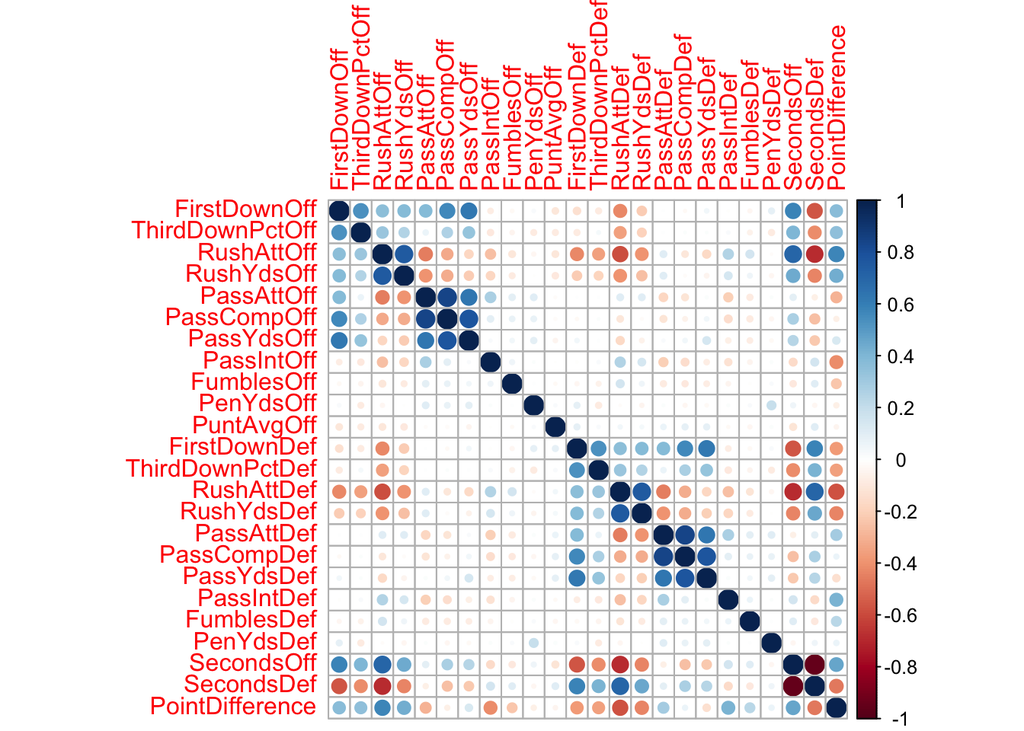

```r
library(corrplot)
corrplot(cor(NFL.4[-c(22)]), method = "circle")
```

We decided to remove variables that had a strong correlation.

```r
NFL.5 <- NFL.4[-c(18,6,4, 15,24,2,13,22)]
head(NFL.5)
```

|  | FirstDownOff | RushAttOff | PassAttOff | PassYdsOff | PassIntOff | FumblesOff | PenYdsOff | PuntAvgOff | FirstDownDef | RushAttDef | PassAttDef | PassCompDef | PassIntDef | FumblesDef | PenYdsDef | SecondsOff | PointDifference |
| --- | --- | --- | --- | --- | --- | --- | --- | --- | --- | --- | --- | --- | --- | --- | --- | --- | --- |
| 1 | 21 | 22 | 46 | 339 | 3 | 0 | 80 | 35 | 13 | 25 | 26 | 16 | 1 | 0 | 29 | 1943 | -3 |
| 2 | 13 | 25 | 26 | 166 | 1 | 0 | 29 | 44 | 21 | 22 | 46 | 28 | 3 | 0 | 80 | 1652 | 3 |
| 3 | 14 | 21 | 36 | 187 | 1 | 0 | 5 | 45 | 21 | 32 | 40 | 28 | 1 | 0 | 56 | 1536 | -8 |
| 4 | 22 | 30 | 23 | 209 | 0 | 1 | 82 | 39 | 29 | 38 | 36 | 25 | 0 | 1 | 15 | 1855 | -3 |
| 5 | 15 | 19 | 34 | 218 | 1 | 0 | 45 | 36 | 15 | 36 | 19 | 12 | 0 | 0 | 35 | 1569 | -3 |
| 6 | 26 | 32 | 39 | 271 | 2 | 1 | 82 | 32 | 18 | 14 | 30 | 24 | 0 | 1 | 90 | 2348 | -6 |

To find the best model, we performed a stepwise regression.

```r
Full=lm(PointDifference~., data=NFL.5)
MSE=(summary(Full)$sigma)^2
none=lm(PointDifference~1, data=NFL.5)
step(none,scope=list(upper=Full), scale=MSE)
```

```
## Start:  AIC=20815.83
## PointDifference ~ 1
##
##                Df Sum of Sq     RSS    Cp
## + RushAttDef    1    467585  934235 11840
## + RushAttOff    1    467112  934708 11849
## + SecondsOff    1    303200 1098620 14996
## + PassIntDef    1    245166 1156655 16110
## + PassIntOff    1    241982 1159838 16172
## + FirstDownDef  1    197979 1203841 17017
## + FirstDownOff  1    197483 1204337 17026
## + PassAttDef    1    123380 1278440 18449
## + PassAttOff    1    122178 1279642 18472
## + FumblesDef    1     79360 1322460 19294
## + FumblesOff    1     77672 1324148 19326
## + PassYdsOff    1     24220 1377600 20353
## + PenYdsDef     1      6180 1395640 20699
## + PenYdsOff     1      5776 1396044 20707
## + PassCompDef   1      5187 1396633 20718
## + PuntAvgOff    1      2751 1399069 20765
## <none>                      1401820 20816
##
## Step:  AIC=11839.91
## PointDifference ~ RushAttDef
##
##                Df Sum of Sq     RSS      Cp
## + RushAttOff    1    121352  812884  9511.9
## + PassIntDef    1    110103  824133  9727.9
## + PassIntOff    1    107491  826744  9778.0
## + PassAttOff    1     76661  857574 10370.0
## + FirstDownDef  1     44511  889725 10987.3
## + FumblesDef    1     42973  891262 11016.8
## + FumblesOff    1     30572  903663 11254.9
## + FirstDownOff  1     29591  904645 11273.7
## + PassCompDef   1     23954  910281 11382.0
## + SecondsOff    1     13273  920962 11587.1
## + PenYdsOff     1      7024  927212 11707.0
## + PenYdsDef     1      2691  931545 11790.2
## + PassAttDef    1      2117  932118 11801.3
## + PassYdsOff    1      2115  932120 11801.3
```

[output cut: 388 more lines]

```
## + RushAttOff    1         0 316937   15.390
## - PuntAvgOff    1       334 317271   17.797
## - PenYdsDef     1      1221 318158   34.833
## - PenYdsOff     1      1230 318167   35.010
## - PassCompDef   1     15662 332599  312.117
## - SecondsOff    1     15889 332826  316.469
## - PassYdsOff    1     33622 350559  656.962
## - FumblesOff    1     48490 365427  942.433
## - PassIntDef    1     48538 365475  943.344
## - FumblesDef    1     49031 365968  952.824
## - PassIntOff    1     52832 369769 1025.793
## - PassAttDef    1     62443 379380 1210.340
## - FirstDownOff  1     82207 399144 1589.808
## - PassAttOff    1    108176 425113 2088.446
## - FirstDownDef  1    129732 446669 2502.330
```

```
##
## Call:
## lm(formula = PointDifference ~ PassIntDef + PassIntOff + PassYdsOff +
##     PassAttOff + FirstDownDef + PassAttDef + FirstDownOff + FumblesOff +
##     FumblesDef + PassCompDef + SecondsOff + PenYdsDef + PenYdsOff +
##     PuntAvgOff, data = NFL.5)
##
## Coefficients:
##  (Intercept)    PassIntDef    PassIntOff    PassYdsOff    PassAttOff
##     18.15076       2.96496      -3.05907       0.04845      -0.70991
## FirstDownDef    PassAttDef  FirstDownOff    FumblesOff    FumblesDef
##     -1.39484       0.79176       1.21903      -3.44156       3.46402
##  PassCompDef    SecondsOff     PenYdsDef     PenYdsOff    PuntAvgOff
##     -0.58854      -0.01009       0.01808      -0.01822       0.03893
```

```r
library(leaps)
all=regsubsets(PointDifference~., data=NFL.5, nbest=2, nvmax=10)
ShowSubsets(all)
```

|  | FirstDownOff | RushAttOff | PassAttOff | PassYdsOff | PassIntOff | FumblesOff | PenYdsOff | PuntAvgOff | FirstDownDef | RushAttDef | PassAttDef | PassCompDef | PassIntDef | FumblesDef | PenYdsDef | SecondsOff | Rsq | adjRsq | Cp |
| --- | --- | --- | --- | --- | --- | --- | --- | --- | --- | --- | --- | --- | --- | --- | --- | --- | --- | --- | --- |
| 1 ( 1 ) |  |  |  |  |  |  |  |  |  | * |  |  |  |  |  |  | 33.36 | 33.34 | 11839.91 |
| 1 ( 2 ) |  | * |  |  |  |  |  |  |  |  |  |  |  |  |  |  | 33.32 | 33.31 | 11848.98 |
| 2 ( 1 ) |  | * |  |  |  |  |  |  |  | * |  |  |  |  |  |  | 42.01 | 41.99 | 9511.88 |
| 2 ( 2 ) |  |  |  |  |  |  |  |  |  | * |  |  | * |  |  |  | 41.21 | 41.19 | 9727.87 |
| 3 ( 1 ) |  |  |  |  | * |  |  |  |  | * |  |  | * |  |  |  | 47.92 | 47.89 | 7923.60 |
| 3 ( 2 ) |  | * |  |  | * |  |  |  |  |  |  |  | * |  |  |  | 47.88 | 47.86 | 7933.31 |
| 4 ( 1 ) | * |  | * |  |  |  |  |  | * |  | * |  |  |  |  |  | 58.93 | 58.90 | 4962.91 |
| 4 ( 2 ) | * |  |  |  | * |  |  |  | * |  | * |  |  |  |  |  | 55.35 | 55.32 | 5925.46 |
| 5 ( 1 ) | * |  | * |  |  |  |  |  | * |  | * |  | * |  |  |  | 63.26 | 63.23 | 3798.40 |
| 5 ( 2 ) | * |  | * |  | * |  |  |  | * |  | * |  |  |  |  |  | 63.22 | 63.19 | 3809.43 |

[output cut: 10 more lines]

From this test, we created a model with the 10 variables that were the most impactful on the model.

```r
mod2=lm(PointDifference~SecondsOff+FumblesDef+PassIntDef+PassAttDef+FirstDownDef+FumblesOff+PassIntOff+FumblesOff+PassIntOff+PassYdsOff+PassAttOff+FirstDownOff, data=NFL.5)
```

Then, we created a plot to show the predicted point difference vs. the actual point difference, and the model was a very good fit.

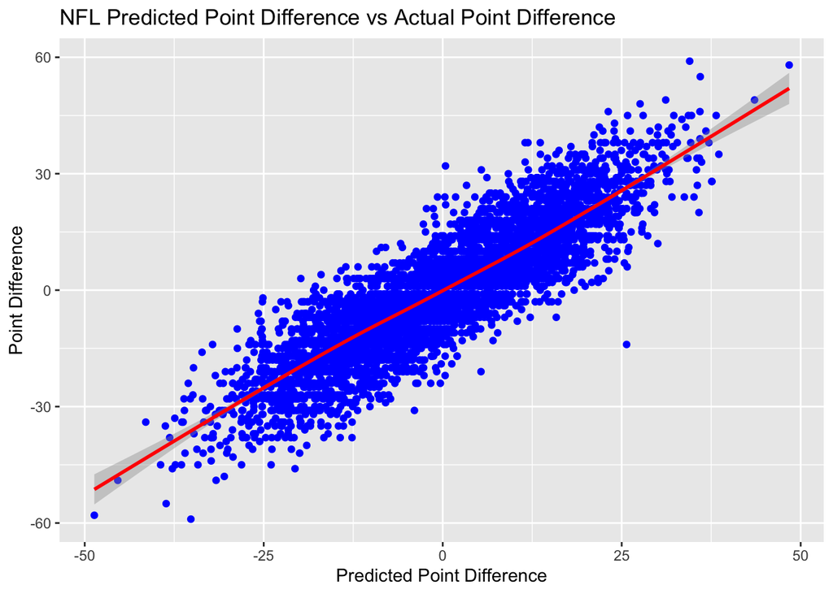

```r
library(ggplot2)
NFL_pred = as.data.frame(predict(mod2, NFL.4))
NFL.6 = cbind(NFL.4, NFL_pred)

ggplot(data = NFL.6, aes(x=NFL.6$`predict(mod2, NFL.4)`,y=NFL.6$PointDifference))+
  geom_point(color="blue")+ geom_smooth(color="red")+xlab('Predicted Point Difference') + ylab('Point Difference') + ggtitle("NFL Predicted Point Difference vs Actual Point Difference")
```

Next, we created a plot to compare the line of the game vs. the actual point difference.

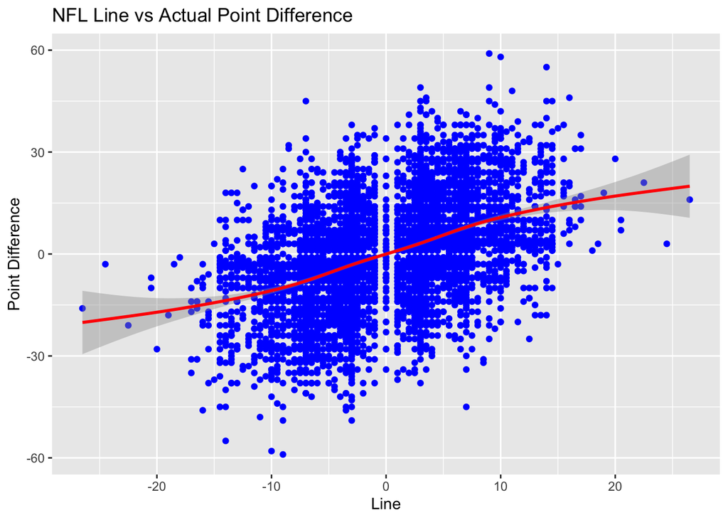

```r
ggplot(data = NFL.6, aes(x=NFL.4$Line, y=NFL.4$PointDifference))+
  geom_point(color="blue")+ geom_smooth(color="red")+xlab('Line') + ylab('Point Difference') + ggtitle("NFL Line vs Actual Point Difference")
```

From this, you can see that our model predicted the point difference much better than the line did. From this, we could use our model with data today to predict more accurate line values for each game.